# tab_mur_10X_P4_3_full

alevinQC (v0.99.0)

2019-06-10

## Version info for alevin run

| Start time | Mon Jun 10 17:07:25 2019 |
| --- | --- |
| Salmon version | 0.13.1 |
| Index | index/Mus_musculus/short_index |
| R1file | data/bamtofastq_S1_L001_R1_001.fastq.gz, data/bamtofastq_S1_L001_R1_002.fastq.gz, data/bamtofastq_S1_L001_R1_003.fastq.gz |
| R2file | data/bamtofastq_S1_L001_R2_001.fastq.gz, data/bamtofastq_S1_L001_R2_002.fastq.gz, data/bamtofastq_S1_L001_R2_003.fastq.gz |
| tgMap | data/mouse_genes_2_tx.tsv |

## Summary tables

#### Full set of cell barcodes

| Total number of processed reads | 136790282 |
| --- | --- |
| Number of reads with valid cell barcode (no Ns) | 136732317 |
| Total number of observed cell barcodes | 903831 |

#### Initial whitelist

| Number of barcodes in initial whitelist | 344 |
| --- | --- |
| Fraction reads in initial whitelist barcodes | 92.64% |
| Mean number of reads per cell (initial whitelist) | 368218 |
| Median number of reads per cell (initial whitelist) | 51927 |
| Median number of detected genes per cell (initial whitelist) | 1025 |
| Total number of detected genes (initial whitelist) | 16568 |
| Median UMI count per cell (initial whitelist) | 2454 |

#### Final whitelist

| Number of barcodes in final whitelist | 136 |
| --- | --- |
| Fraction reads in final whitelist barcodes | 87.57% |
| Mean number of reads per cell (final whitelist) | 880446 |
| Median number of reads per cell (final whitelist) | 741950 |
| Median number of detected genes per cell (final whitelist) | 3692 |
| Total number of detected genes (final whitelist) | 16338 |
| Median UMI count per cell (final whitelist) | 13794 |

## Knee plot

The knee plot displays the number of times each cell barcode is observed, in decreasing order. By finding a ‘knee’ in this plot, Alevin determines a threshold (indicated in the plot) that defines an initial ‘whitelist’ - a set of cell barcodes that likely represent non-empty droplets - and distinguishes them from the background. For this run, the initial whitelist contains 344 cell barcodes, each observed at least 3367 times.

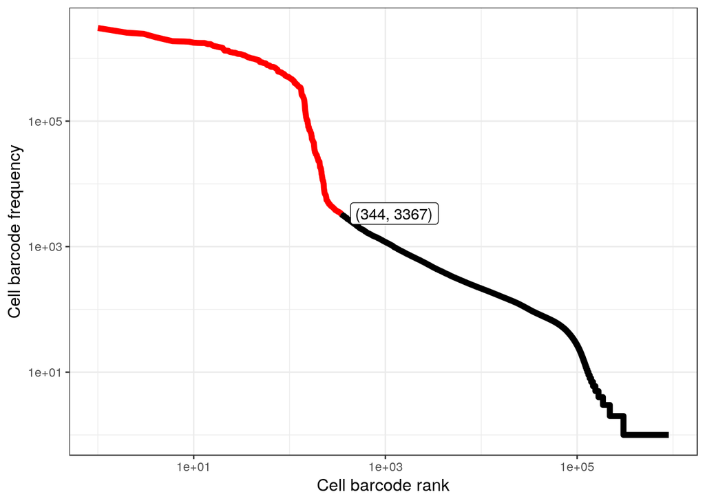

## Cell barcode error correction and merging with initial whitelist

Once the initial set of whitelisted cell barcodes is defined, Alevin goes through the remaining cell barcodes. If a cell barcode is similar enough to a whitelisted cell barcode, it will be corrected and the reads will be added to those of the whitelisted one. The figure below shows the original frequency of the whitelisted barcodes vs the frequency after this correction. The reads corresponding to cell barcodes that can not be corrected to a whitelisted barcode are discarded.

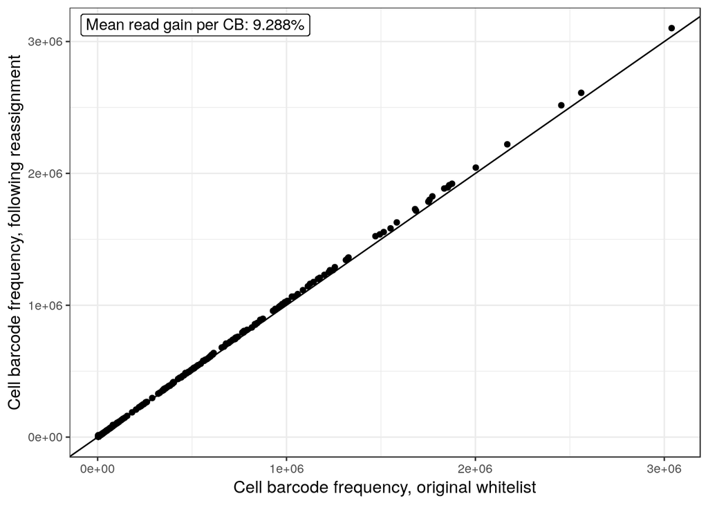

## Quantification

After cell barcode collapsing, Alevin estimates the UMI count for each cell and gene. Following quantification, an additional cell barcode whitelisting is performed with the aim of extracting good quality cells, using not only the barcode frequency but also other features such as the fraction of mapped reads, the duplication rate and the average gene count. The plots below show the association between the cell barcode frequency (the number of observed reads corresponding to a cell barcode), the total UMI count (obtained by summing the UMI counts for the individual genes in the returned count matrix) and the number of detected genes (also obtained from the returned count matrix). The cell barcodes are colored by whether or not they are included in the final whitelist.

These figures can give an indication of whether the sequenced reads actually align to genes, as well as the duplication rate and the degree of saturation. For many droplet data sets, the association between the barcode frequency and the total UMI count is rougly linear, while the association of any of these with the number of detected genes often deviates from linearity, if a small subset of the genes are assigned a large fraction of the UMI counts.

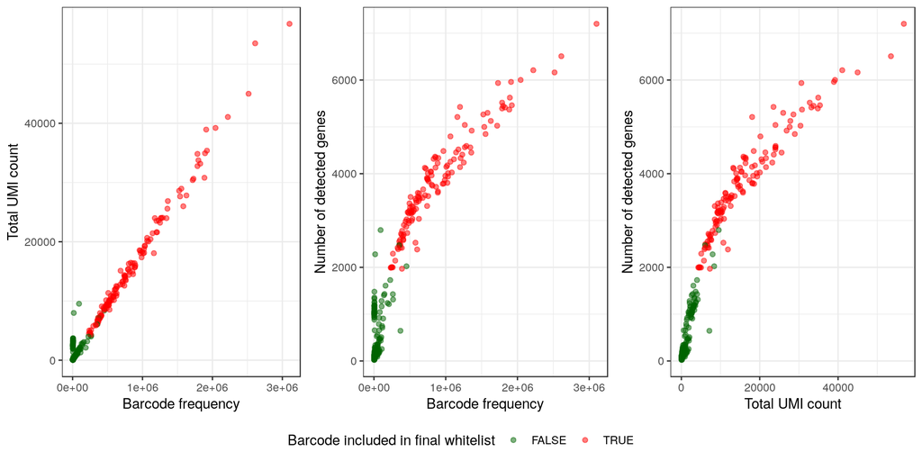

## Knee plot, number of detected genes

Similarly to the knee plot that was used to select the initial cell barcode whitelist, the plot below shows the number of detected genes for each cell barcode included in the initial whitelist, in decreasing order.

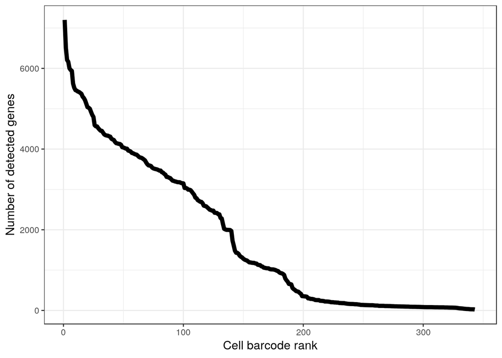